# cm014 Worksheet: The Model-Fitting Paradigm in R

```r
suppressPackageStartupMessages(library(tidyverse))
library(gapminder)
library(broom)
```

So you want to fit a model to your data. How can you achieve this with R?

Topics:

1. What *is* model-fitting?
2. How do we fit a model in R?
3. How can we obtain tidy results from the model output?

## What is Model-Fitting?

When variables are not independent, then we can gain information about one variable if we know something about the other.

Examples: Use the scatterplot below:

1. A car weighs 4000 lbs. What can we say about its mpg? between 15 and 20
2. A car weights less than 3000 lbs. What can we say about its mpg? high mpg

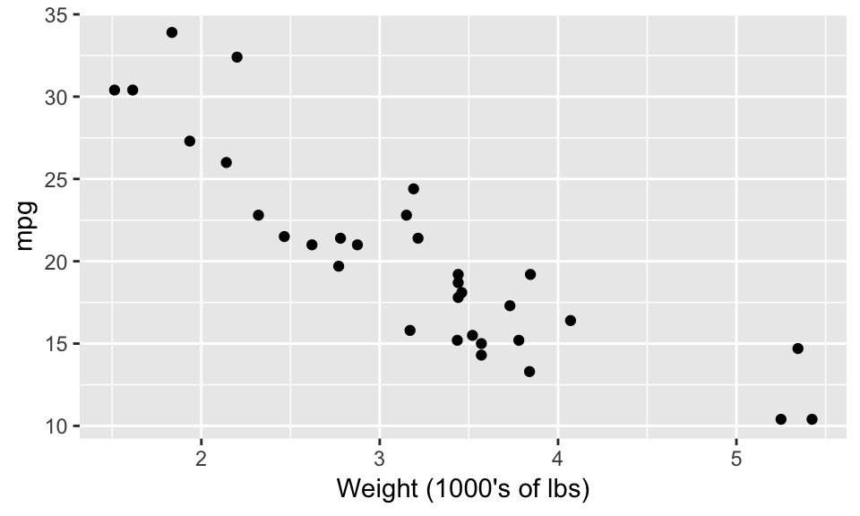

```r
library(tidyverse)
ggplot(mtcars, aes(wt, mpg)) +
  geom_point() +
  labs(x = "Weight (1000's of lbs)")
```

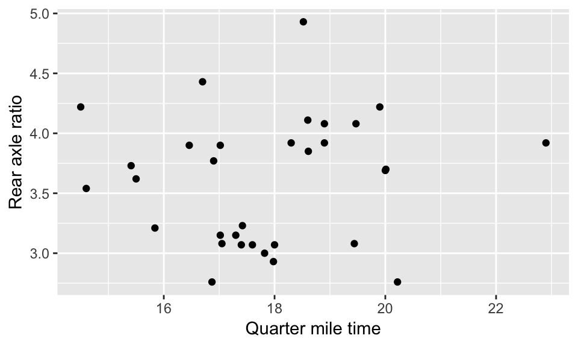

```r
ggplot(mtcars, aes(qsec, drat)) +
  geom_point() +
  labs(x = "Quarter mile time",
       y = "Rear axle ratio")
```

If EDA isn’t enough, we can answer these questions by fitting a model: a curve that predicts Y given X. Aka, a **regression curve** or a **machine learning model**.

(There are more comprehensive models too, such as modelling entire distributions, but that’s not what we’re doing here)

There are typically two goals of fitting a model:

1. Make predictions.
2. Interpret variable relationships.

## Fitting a model in R

Model fitting methods tend to use a common format in R:

```
method(formula, data, options)
```

They also tend to have a common output: a special *list*.

**Method**:

A function such as:

- Linear Regression: `lm`
- Generalized Linear Regression: `glm`
- Local regression: `loess`
- Quantile regression: `quantreg::rq`
- …

**Formula**:

In R, takes the form `y ~ x1 + x2 + ... + xp` (use column names in your data frame).

**Data**: The data frame.

**Options**: Specific to the method.

Exercise:

1. Fit a linear regression model to life expectancy (“Y”) from year (“X”) by filling in the formula. Notice what appears as the output.
2. On a new line, use the `unclass` function to uncover the object’s true nature: a list. Note: it might be easier to use the `names` function to see what components are included in the list.

First, create a subset of the `gapminder` dataset containing only the country of `France

```r
library(gapminder)
(gapminder_France <- gapminder[gapminder$country=="France", ])
```

| country | continent | year | lifeExp | pop | gdpPercap |
| --- | --- | --- | --- | --- | --- |
| France | Europe | 1952 | 67.410 | 42459667 | 7029.809 |
| France | Europe | 1957 | 68.930 | 44310863 | 8662.835 |
| France | Europe | 1962 | 70.510 | 47124000 | 10560.486 |
| France | Europe | 1967 | 71.550 | 49569000 | 12999.918 |
| France | Europe | 1972 | 72.380 | 51732000 | 16107.192 |
| France | Europe | 1977 | 73.830 | 53165019 | 18292.635 |
| France | Europe | 1982 | 74.890 | 54433565 | 20293.897 |
| France | Europe | 1987 | 76.340 | 55630100 | 22066.442 |
| France | Europe | 1992 | 77.460 | 57374179 | 24703.796 |
| France | Europe | 1997 | 78.640 | 58623428 | 25889.785 |

[output cut: 2 more lines]

Now, using the `lm()` function we will create the linear model

```r
(my_lm <- lm(gapminder$lifeExp ~ gapminder$year==2007 ))
```

```
##
## Call:
## lm(formula = gapminder$lifeExp ~ gapminder$year == 2007)
##
## Coefficients:
##                (Intercept)  gapminder$year == 2007TRUE
##                     58.790                       8.218
```

```r
(my_lm <- lm(I(gapminder$lifeExp ~ gapminder$year==1952 )))
```

```
##
## Call:
## lm(formula = I(gapminder$lifeExp ~ gapminder$year == 1952))
##
## Coefficients:
##                (Intercept)  gapminder$year == 1952TRUE
##                      60.42                      -11.36
```

Use the `unclass()` function to take a look at how the `lm()` object actually looks like.

```r
unclass(my_lm)
```

[output not shown]

[output cut: 6246 more lines]

[output not shown]

To complicate things further, some info is stored in *another* list after applying the `summary` function:

```r
summary(my_lm)
```

```
##
## Call:
## lm(formula = I(gapminder$lifeExp ~ gapminder$year == 1952))
##
## Residuals:
##     Min      1Q  Median      3Q     Max
## -36.822 -10.689   1.233  10.779  23.612
##
## Coefficients:
##                            Estimate Std. Error t value Pr(>|t|)
## (Intercept)                 60.4214     0.3171  190.54   <2e-16 ***
## gapminder$year == 1952TRUE -11.3638     1.0985  -10.35   <2e-16 ***
## ---
## Signif. codes:  0 '***' 0.001 '**' 0.01 '*' 0.05 '.' 0.1 ' ' 1
##
## Residual standard error: 12.53 on 1702 degrees of freedom
## Multiple R-squared:  0.05916,    Adjusted R-squared:  0.0586
## F-statistic:   107 on 1 and 1702 DF,  p-value: < 2.2e-16
```

We can use the `predict()` function to make predictions from the model (default is to use fitting/training data). Here are the predictions:

```r
predict(my_lm) %>%
  head()
```

```
##        1        2        3        4        5        6
## 49.05762 60.42142 60.42142 60.42142 60.42142 60.42142
```

```r
years1 = gapminder[gapminder$year==1952,]
predict(my_lm,years1)
```

[output not shown]

[output cut: 371 more lines]

[output not shown]

We can plot models (with one predictor/ X variable) using `ggplot2` through the `geom_smooth()` layer. Specifying `method="lm"` gives us the linear regression fit (but only visually!):

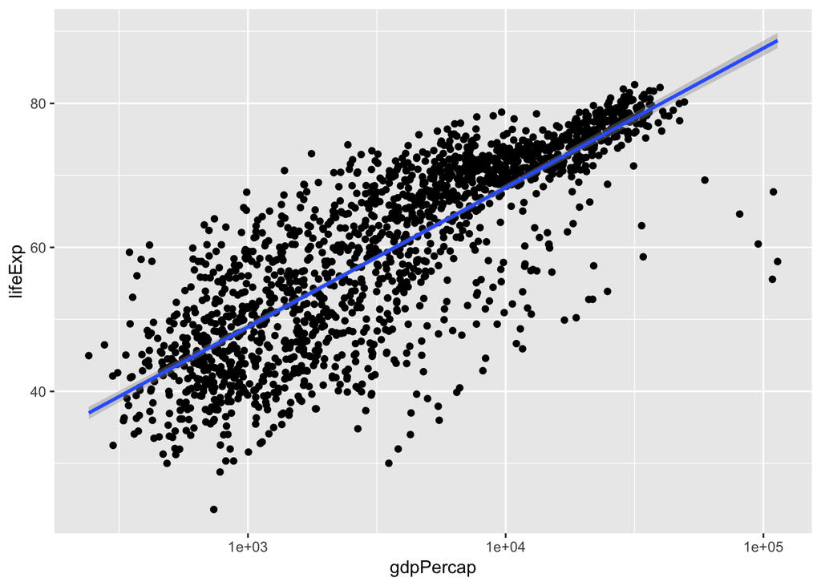

```r
ggplot(gapminder, aes(gdpPercap, lifeExp)) +
    geom_point() +
    geom_smooth(method="lm") +
    scale_x_log10()
```

Lets consider another country “Zimbabwe”, which has a unique behavior in the `lifeExp` and `year` relationship.

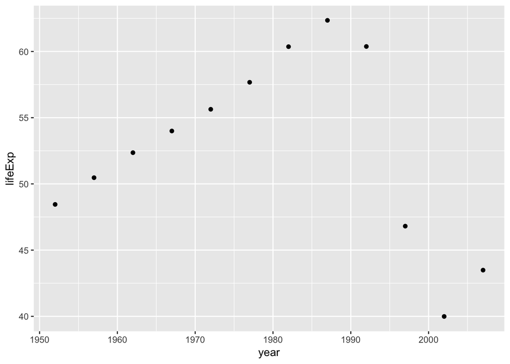

```r
gapminder_Zimbabwe <- gapminder[gapminder$country=="Zimbabwe",]
gapminder_Zimbabwe %>% ggplot(aes(year, lifeExp)) + geom_point()
```

Let’s try fitting a linear model to this relationship

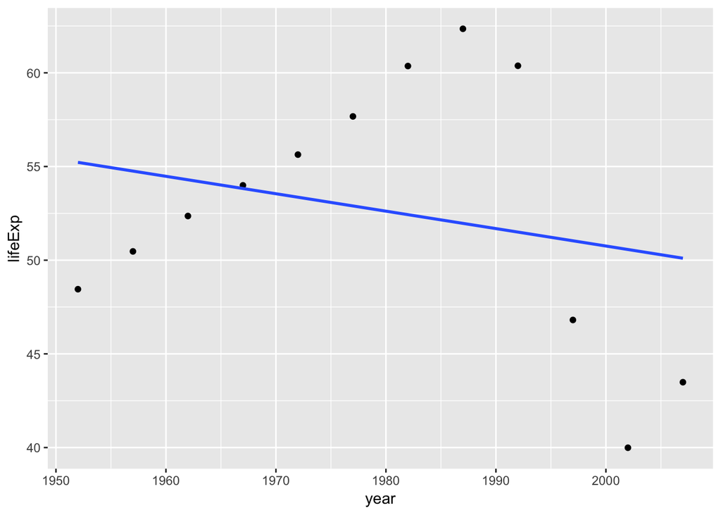

```r
ggplot(gapminder_Zimbabwe, aes(year,lifeExp)) + geom_point()+geom_smooth(method = "lm", se = F)
```

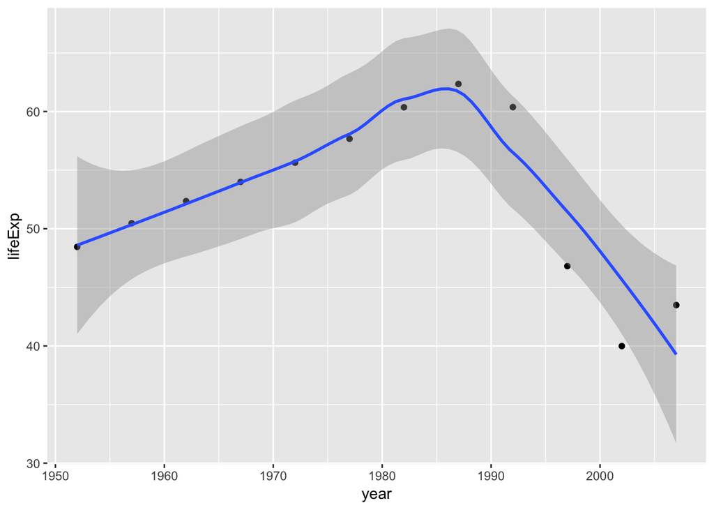

```r
ggplot(gapminder_Zimbabwe, aes(year,lifeExp)) + geom_point()+geom_smooth(method="loess")
```

```r
lm_linear <- lm(data = gapminder,formula = gapminder_Zimbabwe$year ~gapminder_Zimbabwe$lifeExp)
lm_poly <- lm(data = gapminder,formula = gapminder_Zimbabwe$year ~poly(gapminder_Zimbabwe$lifeExp))
```

`anova` lets you compare between different models.

```r
anova(lm_linear,lm_poly)
```

|  | Res.Df | RSS | Df | Sum of Sq | F | Pr(>F) |
| --- | --- | --- | --- | --- | --- | --- |
| 1 | 10 | 3373.971 | NA | NA | NA | NA |
| 2 | 10 | 3373.971 | 0 | -1.818989e-12 | NA | NA |

## Regression with categorical variables

```r
(lm_cat <- lm(gdpPercap ~ I(year - 1952) + continent, data = gapminder))
```

```
##
## Call:
## lm(formula = gdpPercap ~ I(year - 1952) + continent, data = gapminder)
##
## Coefficients:
##       (Intercept)     I(year - 1952)  continentAmericas
##           -1375.3              129.8             4942.4
##     continentAsia    continentEurope   continentOceania
##            5708.4            12275.7            16427.9
```

How did R know that continent was a categorical variable?

```r
class(gapminder$continent)
```

```
## [1] "factor"
```

```r
levels(gapminder$continent)
```

```
## [1] "Africa"   "Americas" "Asia"     "Europe"   "Oceania"
```

```r
contrasts(gapminder$continent)
```

```
##          Americas Asia Europe Oceania
## Africa          0    0      0       0
## Americas        1    0      0       0
## Asia            0    1      0       0
## Europe          0    0      1       0
## Oceania         0    0      0       1
```

How can we change the reference level?

```r
gapminder$continent <- relevel(gapminder$continent, ref = "Oceania")
```

Let’s build a new model

```r
lm_cat2 <- lm(gdpPercap ~ I(year - 1952) + continent, data = gapminder)
```

## Broom

Let’s make it easier to extract info, using the `broom` package. There are three crown functions in this package, all of which input a fitted model, and outputs a tidy data frame.

1. `tidy`: extract statistical summaries about each component of the model.
   - Useful for *interpretation* task.
2. `augment`: add columns to the original data frame, giving information corresponding to each row.
   - Useful for *prediction* task.
3. `glance`: extract statistical summaries about the model as a whole (1-row tibble).
   - Useful for checking goodness of fit.

```r
library(broom)
a<-broom::tidy(lm_cat2)
b<-broom::augment(lm_cat2)
c<-broom::glance(lm_cat2)
```